# HW2 : 석사 2학기 이동규

#### **Library**

```r
#install.packages("rmarkdown")
#install.packages("knitr")
library(ggplot2)
library(dplyr)
library(tidyr)
library(nycflights13)
library(ggthemes) # using in ggplot
library(grid) # can write outside of plot
library(lubridate) # time manipulation package
library(agricolae) # using in scheffe.test
```

#### **1-1. What month had the highest proportion of cancelled flights?**

```r
str(flights)
```

```
## Classes 'tbl_df', 'tbl' and 'data.frame':    336776 obs. of  19 variables:
##  $ year          : int  2013 2013 2013 2013 2013 2013 2013 2013 2013 2013 ...
##  $ month         : int  1 1 1 1 1 1 1 1 1 1 ...
##  $ day           : int  1 1 1 1 1 1 1 1 1 1 ...
##  $ dep_time      : int  517 533 542 544 554 554 555 557 557 558 ...
##  $ sched_dep_time: int  515 529 540 545 600 558 600 600 600 600 ...
##  $ dep_delay     : num  2 4 2 -1 -6 -4 -5 -3 -3 -2 ...
##  $ arr_time      : int  830 850 923 1004 812 740 913 709 838 753 ...
##  $ sched_arr_time: int  819 830 850 1022 837 728 854 723 846 745 ...
##  $ arr_delay     : num  11 20 33 -18 -25 12 19 -14 -8 8 ...
##  $ carrier       : chr  "UA" "UA" "AA" "B6" ...
##  $ flight        : int  1545 1714 1141 725 461 1696 507 5708 79 301 ...
##  $ tailnum       : chr  "N14228" "N24211" "N619AA" "N804JB" ...
##  $ origin        : chr  "EWR" "LGA" "JFK" "JFK" ...
##  $ dest          : chr  "IAH" "IAH" "MIA" "BQN" ...
##  $ air_time      : num  227 227 160 183 116 150 158 53 140 138 ...
##  $ distance      : num  1400 1416 1089 1576 762 ...
##  $ hour          : num  5 5 5 5 6 5 6 6 6 6 ...
##  $ minute        : num  15 29 40 45 0 58 0 0 0 0 ...
##  $ time_hour     : POSIXct, format: "2013-01-01 05:00:00" "2013-01-01 05:00:00" ...
```

```r
sum(is.na(flights)) # The data set has "NA"
```

```
## [1] 46595
```

```r
flights$month<-as.factor(flights$month)
dat1_1_1 <- flights  %>% mutate(cancelled_or_not = is.na(dep_time) & is.na(arr_time) )  %>%  # cancelled = TRUE
  select(month,air_time,cancelled_or_not)  %>% group_by(month)
```

출발시간과 도착시간이 모두 missing인 데이터가 비행기가 취소된 데이터이다.

```r
proportion <- summarize(dat1_1_1 , prop=mean(cancelled_or_not))
proportion
```

```
## # A tibble: 12 x 2
##    month    prop
##    <fct>   <dbl>
##  1 1     0.0193
##  2 2     0.0505
##  3 3     0.0299
##  4 4     0.0236
##  5 5     0.0196
##  6 6     0.0357
##  7 7     0.0319
##  8 8     0.0166
##  9 9     0.0164
## 10 10    0.00817
## 11 11    0.00854
## 12 12    0.0364
```

```r
proportion[which.max(proportion$prop),] # the highest proportion of cancelled flights
```

```
## # A tibble: 1 x 2
##   month   prop
##   <fct>  <dbl>
## 1 2     0.0505
```

#### **1-2-1. What plane (specified by the tailnum variable) traveled the most times from NY city airports in 2013?**

```r
#the most times traveled plane
real_flights = flights %>% filter( !(is.na(dep_time) & is.na(arr_time)))
dat1_2_1 <- real_flights %>% select(tailnum) %>% group_by(tailnum) %>% summarize( count = n() ) %>% filter(!is.na(tailnum))
dat1_2_1[which.max(dat1_2_1$count),]
```

```
## # A tibble: 1 x 2
##   tailnum count
##   <chr>   <int>
## 1 N725MQ    546
```

N725MQ 기종이 NY city를 546번 비행했다. 기본 데이터는 취소된 항공편은 제외하고 생각해야한다.

#### **1-2-2. Plot the number of trips per week over the year.**

```r
dat1_2_2 <- temp <- real_flights %>% select(time_hour,tailnum) %>% mutate( week =  as.factor(yday(time_hour) %/% 7  + 1 ))  %>%
  complete(tailnum,week)%>% filter(tailnum=="N725MQ")  %>% group_by(week) %>% summarize( count = n() )
dat1_2_2$count <- ifelse(temp$count==1 , 0,temp$count)
dat1_2_2[which(dat1_2_2$count==max(dat1_2_2$count)),]
```

```
## # A tibble: 2 x 2
##   week  count
##   <fct> <dbl>
## 1 8        18
## 2 29       18
```

8,29주차에 NY city를 최대로 비행했고, 그 횟수는 18번이다.

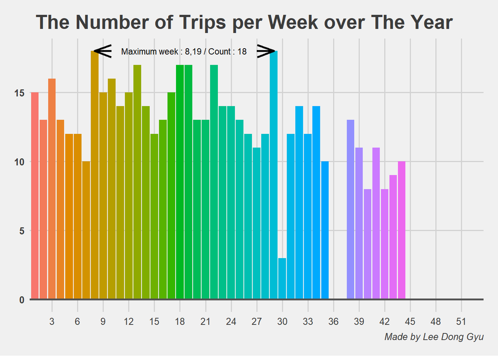

```r
#plot
dat1_2_2 %>% ggplot() +

  #data
  geom_bar(aes(x=week,y=count,fill=week),stat='identity',show.legend = FALSE) +

  #title & caption
  ggtitle(" The Number of Trips per Week over The Year" ) +
  labs(caption = "Made by Lee Dong Gyu" ) +
  scale_x_discrete(breaks = seq(0,53,3) ,labels = seq(0,53,3))+

  #text & arrow
  annotate('segment',x=8,xend=10, y=18 , yend=18, arrow=arrow(ends='first',angle=20),size=1) +
  annotate('segment',x=29,xend=27, y=18 , yend=18, arrow=arrow(ends='first',angle=20),size=1) +
  annotate('text',label = "Maximum week : 8,19 / Count : 18",x=18.5,y=18,size=3,fontface =1) +

  #theme
  theme_fivethirtyeight() +

  theme(plot.title = element_text(face = "bold", size =20)) +
  theme(plot.caption = element_text(face="italic")) +
  theme(axis.text.y = element_text( face = "bold")) +

  geom_hline(yintercept=0 , color = '#545454',size=1)
```

아래는 추가로 공부한 내용이다. 모든 기종들이 주별 NY city를 비행한 횟수이다.

```r
######################### Bonus #########################

dat1_2_2_bonus <- real_flights %>% select(time_hour,tailnum) %>% mutate( week =  as.factor(yday(time_hour) %/% 7  + 1 )) %>%
  group_by(week) %>% summarize( count = n() )

dat1_2_2_bonus[which.max(dat1_2_2_bonus$count),]
```

```
## # A tibble: 1 x 2
##   week  count
##   <fct> <int>
## 1 29     6636
```

29주차에 NY city를 최대로 비행했고, 그 횟수는 6636번이다.

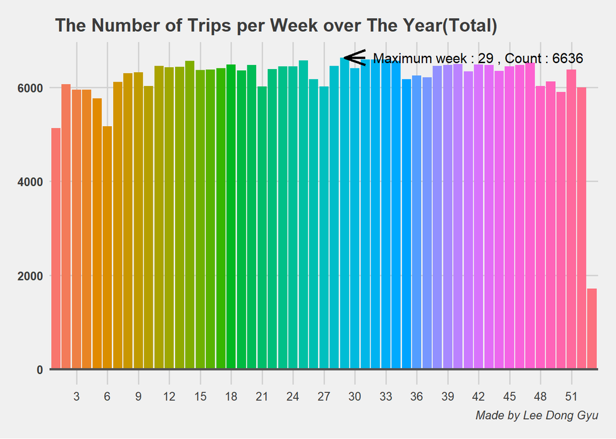

```r
#plot
dat1_2_2_bonus %>% ggplot() +

  #data
  geom_bar(aes(x=week,y=count,fill=week),stat='identity',show.legend = FALSE) +

  #title & caption
  ggtitle(" The Number of Trips per Week over The Year(Total)" ) +
  labs(caption = "Made by Lee Dong Gyu" ) +
  scale_x_discrete(breaks = seq(0,53,3) ,labels = seq(0,53,3))+

  #text & arrow
  annotate('segment',x=29,xend=31, y=6636 , yend=6636, arrow=arrow(ends='first',angle=20),size=1) +
  annotate('text',label = "Maximum week : 29 , Count : 6636",x=42,y=6636,size=4,fontface =1) +

  #theme
  theme_fivethirtyeight() +

  theme(plot.title = element_text(face = "bold", size =15)) +
  theme(plot.caption = element_text(face="italic")) +
  theme(axis.text.y = element_text( face = "bold")) +

  geom_hline(yintercept=0 , color = '#545454',size=1)
```

```r
######################### Bonus End #########################
```

#### **2-1-1. What is the oldest plane (specified by tailnum variable) that flew from NY City airports in 2013?**

```r
# The oldest plane
dat2_1_1 <- planes %>% select(tailnum,year) %>% filter(!is.na(year))
dat2_1_1[with(dat2_1_1,which(year == min(year))),]
```

```
## # A tibble: 1 x 2
##   tailnum  year
##   <chr>   <int>
## 1 N381AA   1956
```

가장 오래된 비행기 기종은 N381AA 이고, 1956년에 만들어졌다.

#### **2-1-2. How many airplanes that flew from NY City are included into the plane data?**

```r
# How many airplanes are included into the plane data
planes_tailnum <- planes %>% select(tailnum)
dat2_1_2 <- flights %>% semi_join(planes_tailnum)
# eqaul to this : dat2_1_2 <- flights %>% filter(tailnum %in% only_tailnum$tailnum)
length(unique(dat2_1_2$tailnum)) # All of the plane data's planes are included in the flights data
```

```
## [1] 3322
```

NY city를 비행한 비행기 중, 3322대의 비행기가 plane data set에 포함되어 있다.

#### **2-2-1. How many planes have a missing date of manufactures?**

```r
# How many planes have a missing date of manufactures?
dat2_2_1 <- planes %>% select(year) %>% filter(is.na(year))
nrow(dat2_2_1)
```

```
## [1] 70
```

#### **2-2-2. What are the five most common manufacturers?**

```r
# What are the five most common manufacturers?
dat2_2_2 <- planes %>% select(manufacturer) %>% group_by(manufacturer) %>% summarize(count=n()) %>% arrange(desc(count))
dat2_2_2 %>%  head(5)
```

```
## # A tibble: 5 x 2
##   manufacturer     count
##   <chr>            <int>
## 1 BOEING            1630
## 2 AIRBUS INDUSTRIE   400
## 3 BOMBARDIER INC     368
## 4 AIRBUS             336
## 5 EMBRAER            299
```

상위 5개는 위와 같다.

#### **2-2-3. Has the distribution of manufacturer changed over time as reflected by the airplanes flying from NYC in 2013?**

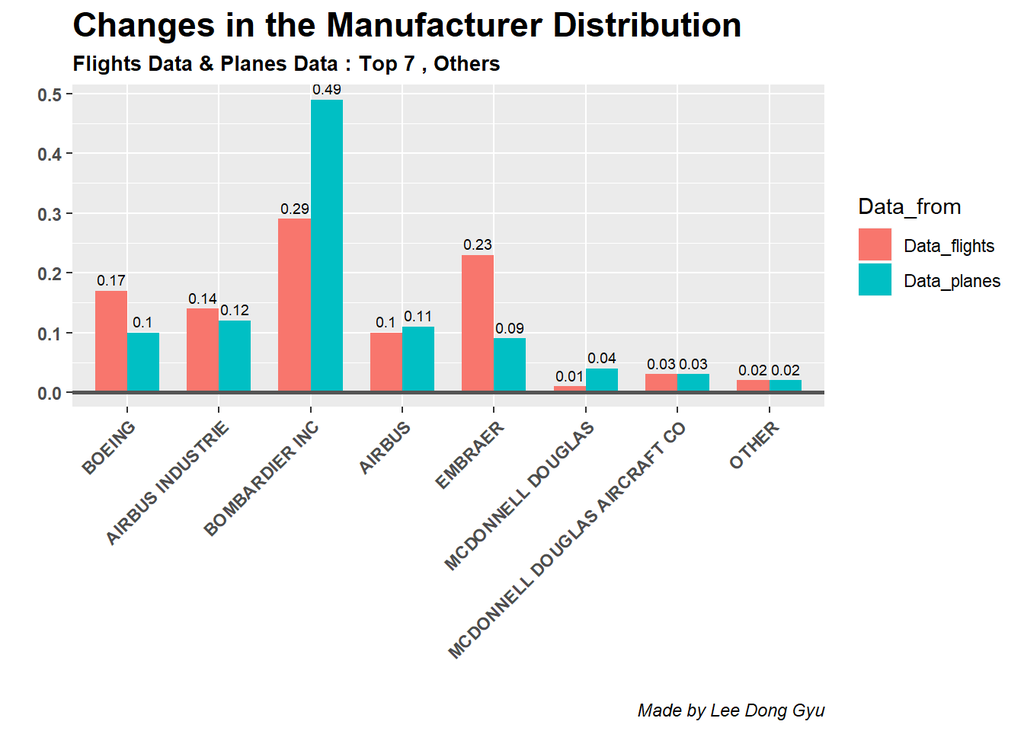

```r
# Has the distribution of manufacturer changed?
count_top_7_planes<- dat2_2_2 %>%  head(7)
count_the_other_sum_planes<- dat2_2_2[8:nrow(dat2_2_2),] %>% select(count) %>% sum()
other1 <- tibble(manufacturer = "OTHER" , count=count_the_other_sum_planes)
dat2_2_3_planes <- count_top_7_planes %>%  rbind(other1) %>% mutate(prop = round(count / sum(count) , 2))


flights_planes_tailnum <- flights %>% inner_join(planes,by='tailnum')
flights_manufacturer_count <- flights_planes_tailnum %>% select(manufacturer) %>% group_by(manufacturer) %>% summarize(count=n()) %>% arrange(desc(count))
count_top_7_flights <- flights_manufacturer_count %>% head(7)
count_the_other_sum_flights <- flights_manufacturer_count[8:nrow(flights_manufacturer_count),] %>% select(count) %>% sum()
other2 <- tibble(manufacturer = "OTHER" , count=count_the_other_sum_flights)
dat2_2_3_flights <- count_top_7_flights %>%  rbind(other2) %>% mutate(prop = round(count / sum(count) , 2))


temp <- dat2_2_3_planes %>% left_join(dat2_2_3_flights , by = "manufacturer") %>%
  select(manufacturer,prop.x , prop.y) %>% rename(Data_planes= prop.x ,Data_flights= prop.y )
final_dat2_2_3 <- temp %>% gather('Data_planes','Data_flights',key="Data_from",value="prop")

#plot
final_dat2_2_3 %>% ggplot(aes(x=manufacturer,y=prop,group=Data_from)) +

  #data
  geom_bar(aes(fill=Data_from),stat='identity',position='dodge',width=0.7) +

  #text
  geom_text(aes(label=final_dat2_2_3$prop), position = position_dodge(width=0.7),size=2.5,vjust=-0.5) +

  #axis
  labs(x="",y="") +
  scale_x_discrete(label = final_dat2_2_3$manufacturer) +

  #title & caption
  ggtitle("Changes in the Manufacturer Distribution" ,subtitle = "Flights Data & Planes Data : Top 7 , Others") +
  labs(caption = "Made by Lee Dong Gyu" ) +

  #theme
  theme(plot.title = element_text(face = "bold", size =17) ) +
  theme(plot.subtitle = element_text(face = "bold", size =10) ) +
  theme(plot.caption = element_text(face="italic")) +
  theme(axis.text.x = element_text( face = "bold",angle=45,hjust=1)) +
  theme(axis.text.y = element_text( face = "bold")) +

  geom_hline(yintercept=0 , color = '#545454',size=1)
```

planes 데이터에서 분포와 flights 데이터에서의 상위7 제조사 분포는 위와 같다.

#### **3-1-1. What is the distribution of temperature in July,2013?**

```r
# Distribution of temp in July, 2013.
new <- weather %>% complete(year,month,day,hour) # Check the implicit missing each day : make new data set.
new %>% select(year,month,day) %>% is.na() %>% sum() # No missing days.
```

```
## [1] 0
```

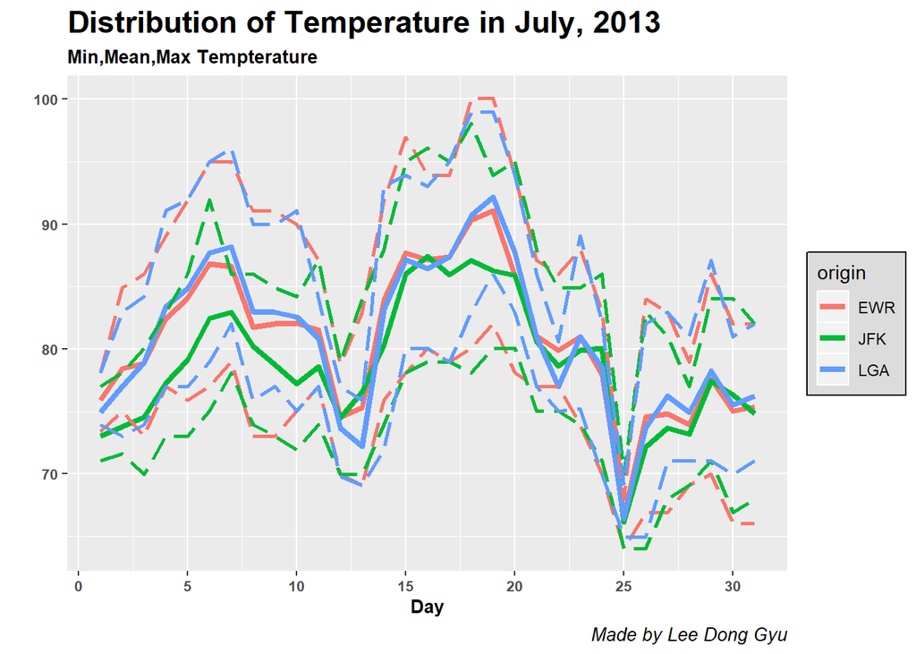

```r
dat3_1_1 <- weather %>% filter(year==2013,month==7) %>% select(origin,year,month,day,hour,temp) %>%
  group_by(origin,month,day) %>% summarize(avg_day_temp = mean(temp,na.rm=T) , max_day_temp = max(temp,na.rm=T) , min_day_temp = min(temp,na.rm=T) )

#plot
dat3_1_1 %>% ggplot(aes(x=day)) +

  #data
  geom_line(aes(y=avg_day_temp,group=origin,color=origin),size=1.5) +
  geom_line(aes(y=max_day_temp,group=origin,color=origin),linetype='longdash',size=1) +
  geom_line(aes(y=min_day_temp,group=origin,color=origin),linetype='longdash',size=1) +

  #axis
  labs(y="",x="Day") +
  scale_x_continuous(breaks = seq(0,30,5) ,labels = seq(0,30,5))+

  #title & caption
  ggtitle("Distribution of Temperature in July, 2013" ,subtitle = "Min,Mean,Max Tempterature") +
  labs(caption = "Made by Lee Dong Gyu" ) +

  #theme
  theme(legend.background = element_rect(fill="gainsboro",color="black")) +

  theme(plot.title = element_text(face = "bold", size =17) ) +
  theme(plot.subtitle = element_text(face = "bold", size =10) ) +
  theme(plot.caption = element_text(face="italic",size=10)) +
  theme(axis.text.x = element_text( face = "bold",size=8)) +
  theme(axis.text.y = element_text( face = "bold",size=8)) +
  theme(axis.title.x = element_text(face = "bold",size=10))
```

점선은 2013년 7월 온도의 최대, 최소를 나타낸 것이며, 실선은 평균값이다.

#### **3-1-2. Identify any important outliers in terms of wind_speed variable.**

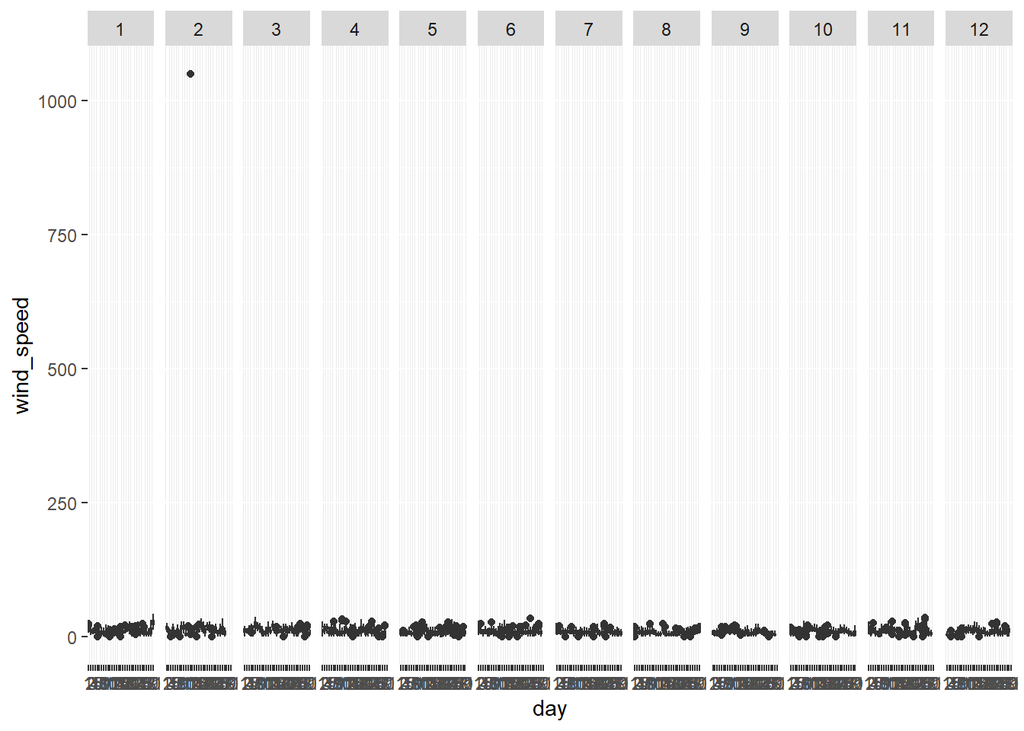

```r
temp<- weather %>% select(origin,month,day,hour,wind_speed,wind_gust)

temp  %>% mutate(day=as.factor(day)) %>%  ggplot() +
  geom_boxplot(aes(x=day,y=wind_speed)) +
  facet_grid(.~month)
```

이상치가 하나 떨어져 있는것을 확인 할 수 있다. 표기오류라 생각하고, 제거해주자.

```r
ind <- which(temp$wind_speed >100) # It might be a writing mistake.
temp$wind_speed[ind]
```

```
## [1] 1048.361
```

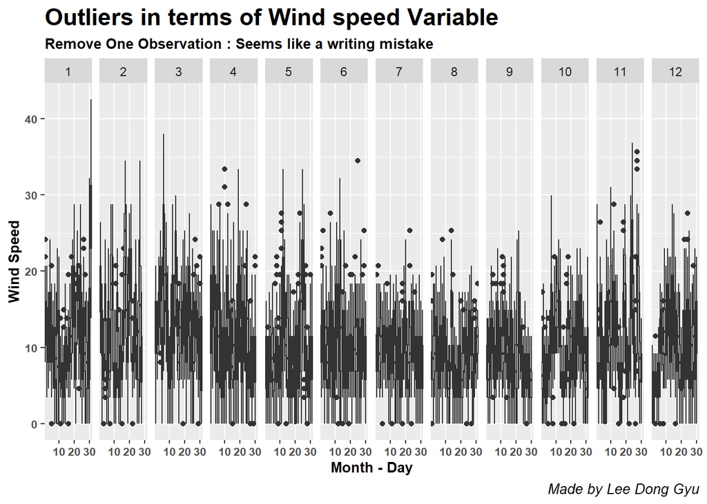

```r
dat3_1_2 <- temp %>% filter(wind_speed < 100)

#plot
dat3_1_2  %>% mutate(day=as.factor(day)) %>%  ggplot() +
  geom_boxplot(aes(x=day,y=wind_speed)) +
  facet_grid(.~month) +

  #axis
  labs(y="Wind Speed",x="Month - Day") +
  scale_x_discrete(breaks = seq(0,30,10) ,labels = seq(0,30,10))+

  #title & caption
  ggtitle("Outliers in terms of Wind speed Variable" ,subtitle = "Remove One Observation : Seems like a writing mistake") +
  labs(caption = "Made by Lee Dong Gyu" ) +

  #theme
  theme(plot.title = element_text(face = "bold", size =17) ) +
  theme(plot.subtitle = element_text(face = "bold", size =10) ) +
  theme(plot.caption = element_text(face="italic",size=10)) +
  theme(axis.text.x = element_text( face = "bold",size=8)) +
  theme(axis.text.y = element_text( face = "bold",size=8)) +
  theme(axis.title.x = element_text(face = "bold",size=10)) +
  theme(axis.title.y = element_text(face = "bold",size=10))
```

각 달 별 일자 대로 box-plot을 그려보았다. 점들이 이상치이다. 40까지 치솟아 있는 것을 확인 할 수 있다.

#### **3-1-3. What is the relationship between dewp and humid?**

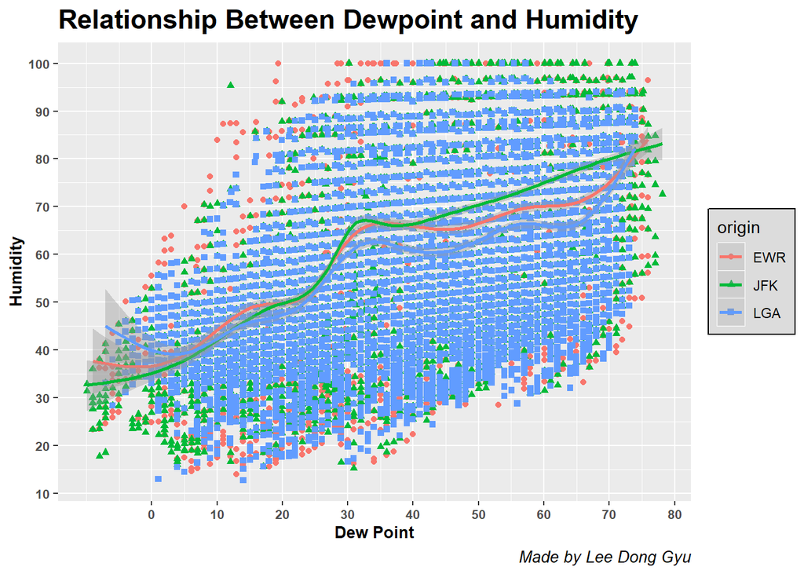

```r
# What is the relationship between dewp and humid?

dat3_1_3 <- weather %>% select(origin,dewp,humid) %>% filter(!is.na(humid),!is.na(dewp)) %>% rename(Dewpoint=dewp,Humidity=humid)

dat3_1_3 %>% ggplot(aes(x=Dewpoint,y=Humidity,shape=origin,col=origin)) +
  geom_point(size=1.5) +
  geom_smooth() +

  #axis
  labs(y="Humidity",x="Dew Point") +
  scale_x_continuous(breaks = seq(0,100,10) ,labels = seq(0,100,10)) +
  scale_y_continuous(breaks = seq(0,100,10) ,labels = seq(0,100,10)) +

  #title & caption
  ggtitle("Relationship Between Dewpoint and Humidity" ) +
  labs(caption = "Made by Lee Dong Gyu" ) +

  #theme
  theme(legend.background = element_rect(fill="gainsboro",color="black")) +
  theme(plot.title = element_text(face = "bold", size =17) ) +
  theme(plot.subtitle = element_text(face = "bold", size =10) ) +
  theme(plot.caption = element_text(face="italic",size=10)) +
  theme(axis.text.x = element_text( face = "bold",size=8)) +
  theme(axis.text.y = element_text( face = "bold",size=8)) +
  theme(axis.title.x = element_text(face = "bold",size=10)) +
  theme(axis.title.y = element_text(face = "bold",size=10))
```

두 변수간의 관계를 origin별로 그린 것이다. 대략적으로 양의 상관관계에 놓여있다.

#### **Bonus**

아래는 추가로 공부해본 것들이다.

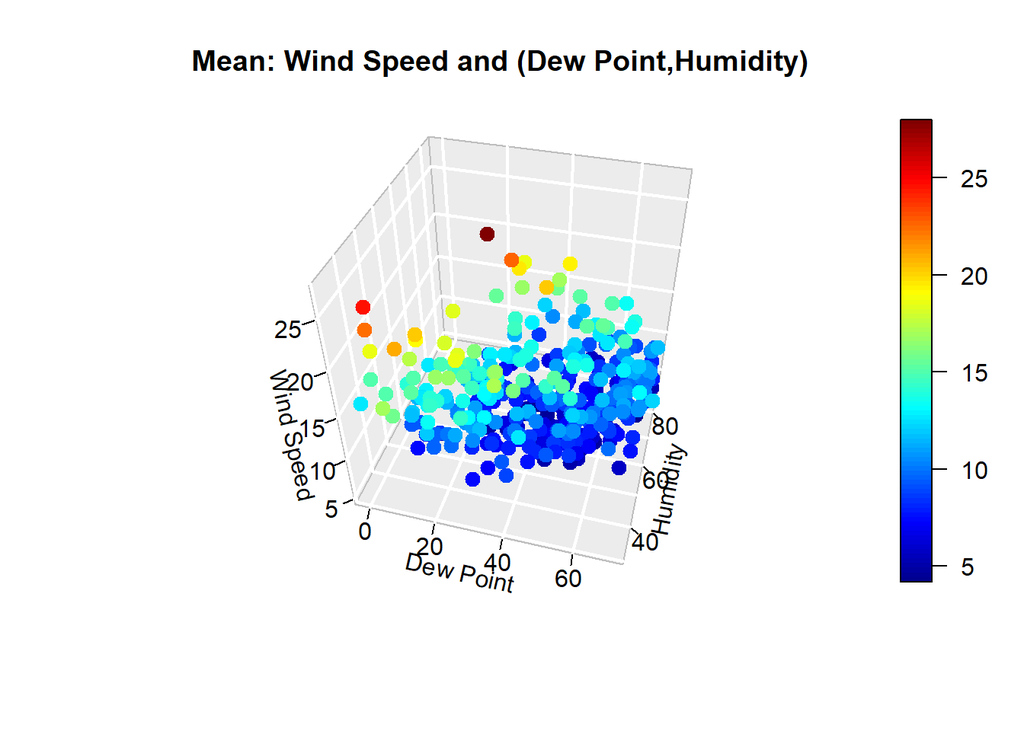

```r
######################### Bonus #########################
# Wind speed & Dewp // Wind speed & Humid
Bonus <- weather %>% select(origin,month,day,wind_speed,dewp,humid) %>% filter(wind_speed < 100 , !is.na(humid),!is.na(dewp)) %>%
  group_by(month,day) %>% summarize(mean_wind_speed = mean(wind_speed),mean_dewp = mean(dewp),mean_humid = mean(humid))

#plot
#3D plot
with(Bonus,plot3D::scatter3D(x=mean_dewp, y=mean_humid, z=mean_wind_speed,
                                main="Mean: Wind Speed and (Dew Point,Humidity)",
                                xlab='Dew Point',theta = 15, d = 2,
                                ylab='Humidity',
                                zlab='Wind Speed',bty = "g",
                                pch = 20, cex = 2,
                                ticktype = "detailed") )
```

세 변수의 관계를 보려면, 삼차원 산점도를 그려야 한다.

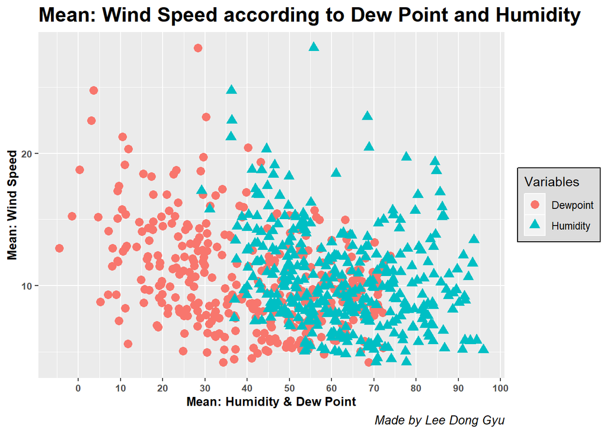

```r
changed_Bonus <- Bonus %>% rename(Dewpoint=mean_dewp, Humidity=mean_humid) %>%
  gather('Dewpoint','Humidity',key="Variables",value="Value")
# Mean Dewp & Mean Wind Speed
changed_Bonus %>% ggplot(aes(x=Value,y=mean_wind_speed)) + geom_point(aes(shape=Variables,col=Variables),size=3) +
  #axis
  labs(y="Mean: Wind Speed",x="Mean: Humidity & Dew Point") +
  scale_x_continuous(breaks = seq(0,100,10) ,labels = seq(0,100,10)) +

  #title & caption
  ggtitle("Mean: Wind Speed according to Dew Point and Humidity" ) +
  labs(caption = "Made by Lee Dong Gyu" ) +

  #theme
  theme(legend.background = element_rect(fill="gainsboro",color="black")) +
  theme(plot.title = element_text(face = "bold", size =17) ) +
  theme(plot.subtitle = element_text(face = "bold", size =10) ) +
  theme(plot.caption = element_text(face="italic",size=10)) +
  theme(axis.text.x = element_text( face = "bold",size=8)) +
  theme(axis.text.y = element_text( face = "bold",size=8)) +
  theme(axis.title.x = element_text(face = "bold",size=10)) +
  theme(axis.title.y = element_text(face = "bold",size=10))
```

```r
######################### Bonus End #########################
```

2차원으로 투영시키면, 위와 같다.

#### **3-2-1. On how many days was there precipitation in the NY are in 2013?**

```r
# NY rain days
weather %>% select(month,day) %>% unique() %>% nrow()
```

```
## [1] 364
```

365개중 한개의 missing이 있는 듯 하다.

```r
weather %>% select(month,day) %>% unique() %>%  group_by(month) %>% summarize(count=n())
```

```
## # A tibble: 12 x 2
##    month count
##    <int> <int>
##  1     1    31
##  2     2    28
##  3     3    31
##  4     4    30
##  5     5    31
##  6     6    30
##  7     7    31
##  8     8    31
##  9     9    30
## 10    10    31
## 11    11    30
## 12    12    30
```

12월에서 missing이 있다.

```r
View(weather %>% select(month,day) %>% unique() %>% filter(month==12) ) # Data set has a missing day on 12/31.

dat3_2_1 <- weather %>% select(year,month,day,hour,precip) %>% mutate(TF_precip = I(precip>0)) %>% select(month,day,TF_precip) %>%
  group_by(month,day) %>% summarize(TF_rain=I(sum(TF_precip)!=0))

temp <- dat3_2_1 %>% select(month,TF_rain) %>% summarize(rain_days=sum(TF_rain))
sum(temp$rain_days)
```

```
## [1] 141
```

2013년 NY city에서 비가 온 날은 141일 이다.

#### **3-2-2. Were there difrerences in the mean visibility (visib) based on the day of the week and/or month of the year?**

```r
# Difrerences mean visibility based on the day of the week and/or month
#bDifrerences mean visibility based on month and day
dat3_2_2_month_day <- weather %>% select(month,day,visib) %>% mutate(month=as.factor(month),day=as.factor(day))

# test Month & Day
test = aov(visib ~ month + day ,dat = dat3_2_2_month_day)
summary(test)
```

```
##                Df Sum Sq Mean Sq F value Pr(>F)
## month          11   4329   393.5   99.66 <2e-16 ***
## day            30   3003   100.1   25.35 <2e-16 ***
## Residuals   26073 102954     3.9
## ---
## Signif. codes:  0 '***' 0.001 '**' 0.01 '*' 0.05 '.' 0.1 ' ' 1
```

두 변수 모두 유의한 값을 지니므로, 각 달,요일별 평균 visibility는 같지 않다.  
그렇다면 같은 그룹을 어떻게 나눌 수 있을까? 다음은 schefee test를 해본 결과이다.

```r
# There exists a difference in monthly or daily average visibility groups
# Then, which day/month?
comparison <- agricolae::scheffe.test(test,'month',group=TRUE,console=TRUE)
```

```
##
## Study: test ~ "month"
##
## Scheffe Test for visib
##
## Mean Square Error  : 3.948684
##
## month,  means
##
##       visib      std    r  Min Max
## 1  8.616280 2.854169 2226 0.00  10
## 10 9.527012 1.487578 2212 0.25  10
## 11 9.528127 1.721780 2141 0.12  10
## 12 8.534184 2.770960 2144 0.00  10
## 2  8.800134 2.572109 2010 0.06  10
## 3  9.324145 2.019828 2227 0.12  10
## 4  9.549194 1.690000 2159 0.12  10
## 5  8.882101 2.511119 2232 0.12  10
## 6  9.316315 1.921043 2160 0.12  10
## 7  9.587522 1.343787 2228 0.50  10
## 8  9.704105 1.059547 2217 0.25  10
## 9  9.662112 1.190694 2159 0.25  10
##
## Alpha: 0.05 ; DF Error: 26073
## Critical Value of F: 1.789015
##
## Groups according to probability of means differences and alpha level( 0.05 )
##
## Means with the same letter are not significantly different.
##
##       visib groups
## 8  9.704105      a
## 9  9.662112      a
## 7  9.587522     ab
## 4  9.549194    abc
## 11 9.528127    abc
## 10 9.527012    abc
## 3  9.324145     bc
## 6  9.316315      c
## 5  8.882101      d
## 2  8.800134     de
## 1  8.616280      e
## 12 8.534184      e
```

```r
comparison <- agricolae::scheffe.test(test,'day',group=TRUE,console=TRUE)
```

```
##
## Study: test ~ "day"
##
## Scheffe Test for visib
##
## Mean Square Error  : 3.948684
##
## day,  means
##
##       visib       std   r  Min Max
## 1  9.546199 1.5218645 855 0.50  10
## 10 9.298780 1.9036993 861 0.25  10
## 11 8.814977 2.5547959 864 0.06  10
## 12 8.625718 2.5571835 864 0.12  10
## 13 8.835534 2.7163716 862 0.12  10
```

[output cut: 66 more lines]

결과를 보고 groups에 있는 알파벳대로 그룹을 나눠주고 해당하는 label을 그룹으로 묶어서 해석하면 된다.